# Define, insert and branch

Daniel Lill

```r
library(dMod)
library(dplyr)
```

# How to set up a coordinate transformation conveniently

dMod provides a set of string manipulating functions which make it easy to simultaneously construct coordinate transformations for many different conditions.

Often, certain parameters of a condition are present in the data itself and it is desirable to insert these parameters into the condition specific transformations. Another case is to individualize parameters by condition to be estimated separately. To this end, the three verbs *define, insert* and *branch* have been introduced as a pipe-friendly manner of introducing different coordinate specific trafos.

We will look at a classic christmas problem the problem of *Santa delivering presents*. The question is if he will make it in time?

## The model of Santa delivering presents

```r
reactions <- NULL %>%
  addReaction("presents_on_sleigh", "presents_delivered", "v * presents_on_sleigh") %>%
  addReaction("v", "", "v * air_resistance") %>%
  addReaction("", "v", "deerpower / (presents_on_sleigh + weight0)")
reactions %>% as.eqnvec()
```

```
## Idx              Inner <- Outer
##   2 presents_delivered <- 1*(v*presents_on_sleigh)
##   1 presents_on_sleigh <- -1*(v*presents_on_sleigh)
##   3                  v <- -1*(v*air_resistance)+1*(deerpower/(presents_on_sleigh+weight0))
```

```r
x <- reactions %>% as.eqnvec() %>% odemodel %>% Xs
```

```
## A shared object with name odemodel already existed and was overwritten.
```

```
## A shared object with name odemodel_s already existed and was overwritten.
```

# The different conditions Santa can choose

There are several options he can choose: Have Rudolph in front of the sleigh, having some presents delivered by amazon or simply delivering fewer presents. To define the several conditions, we define a data.frame containing information about the conditions. Since the **condition.grid** uses rownames to identify the conditions, we assign automatic names to the conditions via *as.condition.grid*.

```r
condition.grid <- tribble(
  ~total_presents,  ~amazon, ~rudolph, ~deerpower,
  1, F, "normal_deer", 2,
  2, F, "normal_deer", 2,
  1, F, "rudolph", 10,
  2, F, "rudolph", 10,
  1, T, "normal_deer", 2,
  2, T, "normal_deer", 2
)
condition.grid <- condition.grid %>% as.data.frame() %>%  as.condition.grid()
print(condition.grid)
```

```
##                       total_presents amazon     rudolph deerpower
## 1_FALSE_normal_deer_2              1  FALSE normal_deer         2
## 2_FALSE_normal_deer_2              2  FALSE normal_deer         2
## 1_FALSE_rudolph_10                 1  FALSE     rudolph        10
## 2_FALSE_rudolph_10                 2  FALSE     rudolph        10
## 1_TRUE_normal_deer_2               1   TRUE normal_deer         2
## 2_TRUE_normal_deer_2               2   TRUE normal_deer         2
```

## Define new equations via *define*

Now let’s build a trafo from that. First, we **define** parameter transformation equations, which means assigning “outer” parameters y to inner parameters “x”.

```r
trafo <- define(NULL, "x~y", x = getParameters(x), y = getParameters(x))
trafo
```

```
## Idx              Inner <- Outer
##   4     air_resistance <- air_resistance
##   5          deerpower <- deerpower
##   2 presents_delivered <- presents_delivered
##   1 presents_on_sleigh <- presents_on_sleigh
##   3                  v <- v
##   6            weight0 <- weight0
```

## Replace existing symbols in equations with *insert*

Let’s do one insertion already: we insert the presents which have been delivered by amazon and use **insert** for that, which replaces symbols in existing trafos. For the second insertion, we can make use of the pipe-friendliness of insert

```r
trafo <- insert(trafo, "presents_on_sleigh~total_presents - amazon_presents") %>%
  insert("presents_delivered ~ amazon_presents")
```

## Make a trafo condition-specific with *branch*

Next, the trafos are going to be made condition-specific, we **branch** them. Now, we have a list of trafos the names of which are the condition names. Furthermore, the condition.grid is stored as an attribute called “tree”, whose variables can now be used in define.

```r
trafo <- branch(trafo, condition.grid)
attr(trafo, "tree")
```

```
##                       total_presents amazon     rudolph deerpower
## 1_FALSE_normal_deer_2              1  FALSE normal_deer         2
## 2_FALSE_normal_deer_2              2  FALSE normal_deer         2
## 1_FALSE_rudolph_10                 1  FALSE     rudolph        10
## 2_FALSE_rudolph_10                 2  FALSE     rudolph        10
## 1_TRUE_normal_deer_2               1   TRUE normal_deer         2
## 2_TRUE_normal_deer_2               2   TRUE normal_deer         2
```

let’s look at this trafo in a table: It’s the same everywhere

```r
prettyprint_trafo <- function(trafo) {
  eqnnames <- names(trafo[[1]])
  trafo %>% do.call(c,.) %>%
    matrix(nrow = length(eqnnames), dimnames = list(eqnnames, names(trafo))) %>% as.data.frame(stringsAsFactors = F)
}
prettyprint_trafo(trafo)
```

```
##                             1_FALSE_normal_deer_2
## presents_on_sleigh total_presents-amazon_presents
## presents_delivered                amazon_presents
## v                                               v
## air_resistance                     air_resistance
## deerpower                               deerpower
## weight0                                   weight0
##                             2_FALSE_normal_deer_2
## presents_on_sleigh total_presents-amazon_presents
## presents_delivered                amazon_presents
## v                                               v
## air_resistance                     air_resistance
## deerpower                               deerpower
## weight0                                   weight0
##                                1_FALSE_rudolph_10
## presents_on_sleigh total_presents-amazon_presents
## presents_delivered                amazon_presents
## v                                               v
## air_resistance                     air_resistance
## deerpower                               deerpower
## weight0                                   weight0
##                                2_FALSE_rudolph_10
## presents_on_sleigh total_presents-amazon_presents
## presents_delivered                amazon_presents
## v                                               v
## air_resistance                     air_resistance
## deerpower                               deerpower
## weight0                                   weight0
##                              1_TRUE_normal_deer_2
## presents_on_sleigh total_presents-amazon_presents
## presents_delivered                amazon_presents
## v                                               v
## air_resistance                     air_resistance
## deerpower                               deerpower
## weight0                                   weight0
##                              2_TRUE_normal_deer_2
## presents_on_sleigh total_presents-amazon_presents
## presents_delivered                amazon_presents
## v                                               v
## air_resistance                     air_resistance
## deerpower                               deerpower
## weight0                                   weight0
```

## Use condition.grid to subset conditions for insertions

Let’s first insert the effect that amazon deliveries have. For those conditions when amazon evaluates to F, we want a zero to be inserted for amazon_presents. The …-argument for define can handle boolean expressions based on the condition.grid and uses them to subset the conditions for which the insertions are done.

```r
trafo <- insert(trafo, "x~0", x = "amazon_presents", amazon ==F)
prettyprint_trafo(trafo)
```

```
##                    1_FALSE_normal_deer_2 2_FALSE_normal_deer_2
## presents_on_sleigh      total_presents-0      total_presents-0
## presents_delivered                     0                     0
## v                                      v                     v
## air_resistance            air_resistance        air_resistance
## deerpower                      deerpower             deerpower
## weight0                          weight0               weight0
##                    1_FALSE_rudolph_10 2_FALSE_rudolph_10
## presents_on_sleigh   total_presents-0   total_presents-0
## presents_delivered                  0                  0
## v                                   v                  v
## air_resistance         air_resistance     air_resistance
## deerpower                   deerpower          deerpower
## weight0                       weight0            weight0
##                              1_TRUE_normal_deer_2
## presents_on_sleigh total_presents-amazon_presents
## presents_delivered                amazon_presents
## v                                               v
## air_resistance                     air_resistance
## deerpower                               deerpower
## weight0                                   weight0
##                              2_TRUE_normal_deer_2
## presents_on_sleigh total_presents-amazon_presents
## presents_delivered                amazon_presents
## v                                               v
## air_resistance                     air_resistance
## deerpower                               deerpower
## weight0                                   weight0
```

## Use condition.grid to insert values from it

Next, we insert the parameter values which are given directly in the condition.grid. The …-argument can also be used to access values from the condition.grid, in a condition-specific manner.

```r
trafo <- insert(trafo, "name~value", name = "total_presents", value = total_presents) %>%
  insert("name~value", name = "deerpower", value = deerpower)
prettyprint_trafo(trafo)
```

```
##                    1_FALSE_normal_deer_2 2_FALSE_normal_deer_2
## presents_on_sleigh                   1-0                   2-0
## presents_delivered                     0                     0
## v                                      v                     v
## air_resistance            air_resistance        air_resistance
## deerpower                              2                     2
## weight0                          weight0               weight0
##                    1_FALSE_rudolph_10 2_FALSE_rudolph_10
## presents_on_sleigh                1-0                2-0
## presents_delivered                  0                  0
## v                                   v                  v
## air_resistance         air_resistance     air_resistance
## deerpower                          10                 10
## weight0                       weight0            weight0
##                    1_TRUE_normal_deer_2 2_TRUE_normal_deer_2
## presents_on_sleigh    1-amazon_presents    2-amazon_presents
## presents_delivered      amazon_presents      amazon_presents
## v                                     v                    v
## air_resistance           air_resistance       air_resistance
## deerpower                             2                    2
## weight0                         weight0              weight0
```

Note that we could have solved this also generically with mget, for this, read ?insert

## Use condition.grid to personalize symbolic parameters for estimation

We can also assume that the air_resistance of the sleigh is lower when rudolph is at the front, therefore we need new individualized parameters

```r
trafo <- insert(trafo, "resistance ~ resistance_rudi", resistance = "air_resistance", rudi = rudolph)
prettyprint_trafo(trafo)
```

```
##                         1_FALSE_normal_deer_2      2_FALSE_normal_deer_2
## presents_on_sleigh                        1-0                        2-0
## presents_delivered                          0                          0
## v                                           v                          v
## air_resistance     air_resistance_normal_deer air_resistance_normal_deer
## deerpower                                   2                          2
## weight0                               weight0                    weight0
##                        1_FALSE_rudolph_10     2_FALSE_rudolph_10
## presents_on_sleigh                    1-0                    2-0
## presents_delivered                      0                      0
## v                                       v                      v
## air_resistance     air_resistance_rudolph air_resistance_rudolph
## deerpower                              10                     10
## weight0                           weight0                weight0
##                          1_TRUE_normal_deer_2       2_TRUE_normal_deer_2
## presents_on_sleigh          1-amazon_presents          2-amazon_presents
## presents_delivered            amazon_presents            amazon_presents
## v                                           v                          v
## air_resistance     air_resistance_normal_deer air_resistance_normal_deer
## deerpower                                   2                          2
## weight0                               weight0                    weight0
```

## Use the argument .currentSymbols to access the condition-specific parameters

We now want to log-transform the parameters, but we would need to supply the newly created parameter names such as “air_resistance_rudolph” and all other parameter names to define(). This is too cumbersome, therefore the .currentSymbols-variable has been introduced to access the current parameters existing in each individual parameter transformation. However, we want to exclude “v” from the log-transformation and we can conveniently do so

```r
trafo <- insert(trafo, "x~exp(x)", x = .currentSymbols[!.currentSymbols %in% "v"])
prettyprint_trafo(trafo)
```

```
##                              1_FALSE_normal_deer_2
## presents_on_sleigh                             1-0
## presents_delivered                               0
## v                                                v
## air_resistance     exp(air_resistance_normal_deer)
## deerpower                                        2
## weight0                               exp(weight0)
##                              2_FALSE_normal_deer_2
## presents_on_sleigh                             2-0
## presents_delivered                               0
## v                                                v
## air_resistance     exp(air_resistance_normal_deer)
## deerpower                                        2
## weight0                               exp(weight0)
##                             1_FALSE_rudolph_10          2_FALSE_rudolph_10
## presents_on_sleigh                         1-0                         2-0
## presents_delivered                           0                           0
## v                                            v                           v
## air_resistance     exp(air_resistance_rudolph) exp(air_resistance_rudolph)
## deerpower                                   10                          10
## weight0                           exp(weight0)                exp(weight0)
##                               1_TRUE_normal_deer_2
## presents_on_sleigh          1-exp(amazon_presents)
## presents_delivered            exp(amazon_presents)
## v                                                v
## air_resistance     exp(air_resistance_normal_deer)
## deerpower                                        2
## weight0                               exp(weight0)
##                               2_TRUE_normal_deer_2
## presents_on_sleigh          2-exp(amazon_presents)
## presents_delivered            exp(amazon_presents)
## v                                                v
## air_resistance     exp(air_resistance_normal_deer)
## deerpower                                        2
## weight0                               exp(weight0)
```

# Build parameter trafo function

From this trafo, a parameter transformation function can be readily created, which, if the condition.grid originates from the original data, matches the original conditions exactly.

```r
p <- P(trafo)
```

# So, will Santa make it in time?

Apparently, Rudolph is indispensable for delivering many presents in time, but Amazon can help if there are not so many presents on the sleigh.

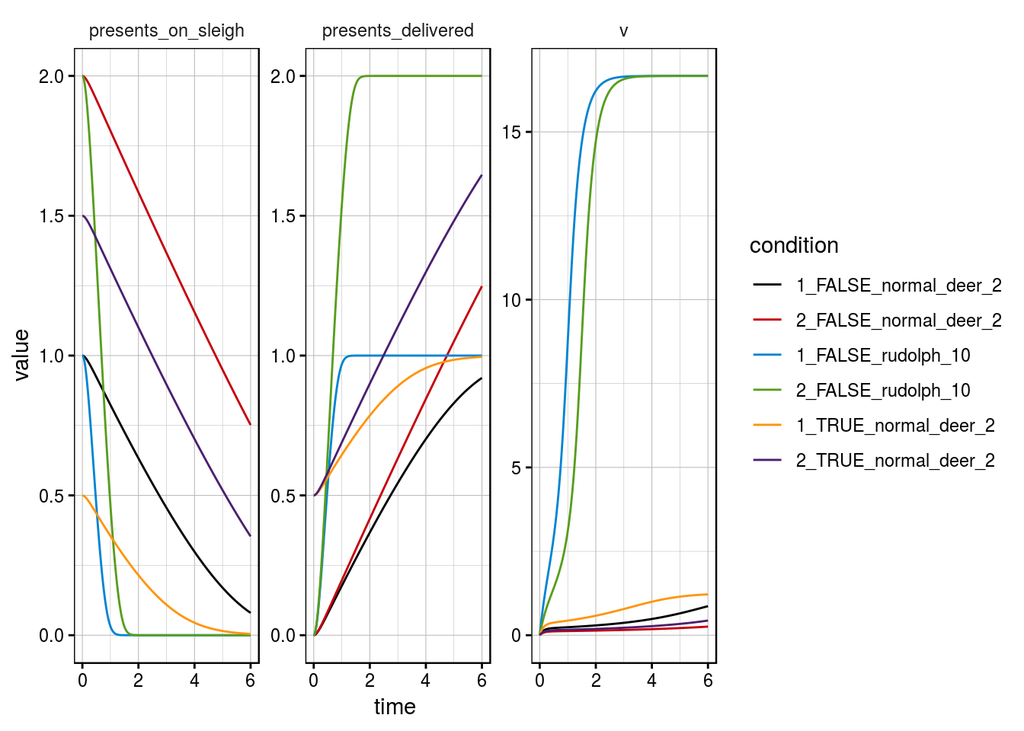

```r
pars <- c(
  air_resistance_normal_deer    =   log(8)  , # 1
  air_resistance_rudolph        =   log(3)  , # 2
  amazon_presents               =   log(.5) , # 4
  v                             =   0   , # 5
  weight0                       =   log(0.2)      # 6
)
plot((x*p)(seq(0,6,0.01), pars))
```

## Remarks on the pipe-friendliness

The functions are fully pipe-friendly, enabling streamlined construction of symbolic functions. For example, the trafo in this examply could be coded in these few simply lines.

```r
trafo <- NULL %>%
  define( "x~y", x = getParameters(x), y = getParameters(x)) %>%
  insert("presents_on_sleigh~total_presents - amazon_presents") %>%
  insert("presents_delivered ~ amazon_presents") %>%
  branch(condition.grid) %>%
  insert("x~0", x = "amazon_presents", amazon == F) %>%
  insert("name~value", name = "total_presents", value = total_presents) %>%
  insert("name~value", name = "deerpower", value = deerpower) %>%
  insert("resistance ~ resistance_rudi", resistance = "air_resistance", rudi = rudolph) %>%
  insert("x~exp(x)", x = .currentSymbols[!.currentSymbols %in% "v"])
prettyprint_trafo(trafo)
```

```
##                              1_FALSE_normal_deer_2
## presents_on_sleigh                             1-0
## presents_delivered                               0
## v                                                v
## air_resistance     exp(air_resistance_normal_deer)
## deerpower                                        2
## weight0                               exp(weight0)
##                              2_FALSE_normal_deer_2
## presents_on_sleigh                             2-0
## presents_delivered                               0
## v                                                v
## air_resistance     exp(air_resistance_normal_deer)
## deerpower                                        2
## weight0                               exp(weight0)
##                             1_FALSE_rudolph_10          2_FALSE_rudolph_10
## presents_on_sleigh                         1-0                         2-0
## presents_delivered                           0                           0
## v                                            v                           v
## air_resistance     exp(air_resistance_rudolph) exp(air_resistance_rudolph)
## deerpower                                   10                          10
## weight0                           exp(weight0)                exp(weight0)
##                               1_TRUE_normal_deer_2
## presents_on_sleigh          1-exp(amazon_presents)
## presents_delivered            exp(amazon_presents)
## v                                                v
## air_resistance     exp(air_resistance_normal_deer)
## deerpower                                        2
## weight0                               exp(weight0)
##                               2_TRUE_normal_deer_2
## presents_on_sleigh          2-exp(amazon_presents)
## presents_delivered            exp(amazon_presents)
## v                                                v
## air_resistance     exp(air_resistance_normal_deer)
## deerpower                                        2
## weight0                               exp(weight0)
```